# Cyclistic Analysis

## **Phase 4: Analyze**

I will now check the statistical summary for the dataset.

```r
summary(BD_0523_filtered)
```

```
##    ride_id          rideable_type       started_at          ended_at
##  Length:343353      Length:343353      Length:343353      Length:343353
##  Class :character   Class :character   Class :character   Class :character
##  Mode  :character   Mode  :character   Mode  :character   Mode  :character
##
##
##
##
##  start_station_name end_station_name   member_casual      day_of_week
##  Length:343353      Length:343353      Length:343353      Sun:41255
##  Class :character   Class :character   Class :character   Mon:44911
##  Mode  :character   Mode  :character   Mode  :character   Tue:60642
##                                                           Wed:60094
##                                                           Thu:50079
##                                                           Fri:43406
##                                                           Sat:42966
##   ride_length
##  Min.   :  11.0
##  1st Qu.: 299.0
##  Median : 485.0
##  Mean   : 522.2
##  3rd Qu.: 726.0
##  Max.   :1139.0
##
```

```r
BD_0523_filtered %>%
  count(start_station_name, sort = TRUE) %>%
  slice(1:5)
```

| start_station_name | n |
| --- | --- |
| Streeter Dr & Grand Ave | 3070 |
| Kingsbury St & Kinzie St | 2744 |
| Wells St & Concord Ln | 2656 |
| Clark St & Elm St | 2629 |
| University Ave & 57th St | 2488 |

```r
BD_0523_filtered %>%
  count(end_station_name, sort = TRUE) %>%
  slice(1:5)
```

| end_station_name | n |
| --- | --- |
| Streeter Dr & Grand Ave | 2904 |
| Kingsbury St & Kinzie St | 2838 |
| Wells St & Concord Ln | 2723 |
| University Ave & 57th St | 2664 |
| Clinton St & Washington Blvd | 2628 |

```r
BD_0523_filtered %>%
  count(rideable_type, sort = TRUE) %>%
  slice(1:5)
```

| rideable_type | n |
| --- | --- |
| classic_bike | 192744 |
| electric_bike | 146808 |
| docked_bike | 3801 |

```r
BD_0523_filtered %>%
  count(member_casual, sort = TRUE) %>%
  slice(1:5)
```

| member_casual | n |
| --- | --- |
| member | 232810 |
| casual | 110543 |

Deductions:

- Users who use the bikes for work commuting are not using them as often on the weekend.
- A large amount of users will get a bike at the start of their work day and return it after.
- A large amount of users are starting their trip at a very touristy area.

Now, we can look at the specific stats for both Casuals and Members. Lets start with Casuals.

```r
BD_0523_filtered_c <- BD_0523_filtered %>%
  filter(member_casual == 'casual')
summary(BD_0523_filtered_c)
```

```
##    ride_id          rideable_type       started_at          ended_at
##  Length:110543      Length:110543      Length:110543      Length:110543
##  Class :character   Class :character   Class :character   Class :character
##  Mode  :character   Mode  :character   Mode  :character   Mode  :character
##
##
##
##
##  start_station_name end_station_name   member_casual      day_of_week
##  Length:110543      Length:110543      Length:110543      Sun:17588
##  Class :character   Class :character   Class :character   Mon:13368
##  Mode  :character   Mode  :character   Mode  :character   Tue:16836
##                                                           Wed:16429
##                                                           Thu:14504
##                                                           Fri:14229
##                                                           Sat:17589
##   ride_length
##  Min.   :  11.0
##  1st Qu.: 350.0
##  Median : 550.0
##  Mean   : 570.1
##  3rd Qu.: 786.0
##  Max.   :1139.0
##
```

```r
BD_0523_filtered_c %>%
  count(start_station_name, sort = TRUE) %>%
  slice(1:5)
```

| start_station_name | n |
| --- | --- |
| Streeter Dr & Grand Ave | 1942 |
| DuSable Lake Shore Dr & Monroe St | 1323 |
| DuSable Lake Shore Dr & North Blvd | 1080 |
| Michigan Ave & Oak St | 950 |
| Wells St & Concord Ln | 923 |

```r
BD_0523_filtered_c %>%
  count(end_station_name, sort = TRUE) %>%
  slice(1:5)
```

| end_station_name | n |
| --- | --- |
| Streeter Dr & Grand Ave | 2032 |
| DuSable Lake Shore Dr & Monroe St | 1176 |
| DuSable Lake Shore Dr & North Blvd | 1125 |
| Millennium Park | 1066 |
| Michigan Ave & Oak St | 956 |

```r
BD_0523_filtered_c %>%
  count(rideable_type, sort = TRUE) %>%
  slice(1:5)
```

| rideable_type | n |
| --- | --- |
| classic_bike | 53533 |
| electric_bike | 53209 |
| docked_bike | 3801 |

```r
BD_0523_filtered_c %>%
  count(member_casual, sort = TRUE) %>%
  slice(1:5)
```

| member_casual | n |
| --- | --- |
| casual | 110543 |

Deductions:

- Casuals are using their bike more often on the weekends.
- Casuals trip length is longer than the population’s average.
- Casuals are starting and ending their trips similar to the population.

Now, lets look at Annual Members

```r
BD_0523_filtered_m <- BD_0523_filtered %>%
  filter(member_casual == 'member')
summary(BD_0523_filtered_m)
```

```
##    ride_id          rideable_type       started_at          ended_at
##  Length:232810      Length:232810      Length:232810      Length:232810
##  Class :character   Class :character   Class :character   Class :character
##  Mode  :character   Mode  :character   Mode  :character   Mode  :character
##
##
##
##
##  start_station_name end_station_name   member_casual      day_of_week
##  Length:232810      Length:232810      Length:232810      Sun:23667
##  Class :character   Class :character   Class :character   Mon:31543
##  Mode  :character   Mode  :character   Mode  :character   Tue:43806
##                                                           Wed:43665
##                                                           Thu:35575
##                                                           Fri:29177
##                                                           Sat:25377
##   ride_length
##  Min.   :  11.0
##  1st Qu.: 281.0
##  Median : 456.0
##  Mean   : 499.4
##  3rd Qu.: 693.0
##  Max.   :1139.0
##
```

```r
BD_0523_filtered_m %>%
  count(start_station_name, sort = TRUE) %>%
  slice(1:5)
```

| start_station_name | n |
| --- | --- |
| Kingsbury St & Kinzie St | 2047 |
| Clinton St & Washington Blvd | 1943 |
| University Ave & 57th St | 1863 |
| Clark St & Elm St | 1849 |
| Ellis Ave & 60th St | 1822 |

```r
BD_0523_filtered_m %>%
  count(end_station_name, sort = TRUE) %>%
  slice(1:5)
```

| end_station_name | n |
| --- | --- |
| Clinton St & Washington Blvd | 2191 |
| Kingsbury St & Kinzie St | 2135 |
| University Ave & 57th St | 2022 |
| Clark St & Elm St | 1917 |
| Wells St & Concord Ln | 1828 |

```r
BD_0523_filtered_m %>%
  count(rideable_type, sort = TRUE) %>%
  slice(1:5)
```

| rideable_type | n |
| --- | --- |
| classic_bike | 139211 |
| electric_bike | 93599 |

```r
BD_0523_filtered_m %>%
  count(member_casual, sort = TRUE) %>%
  slice(1:5)
```

| member_casual | n |
| --- | --- |
| member | 232810 |

Deductions:

- Members are using their bike more often in the middle of the week.
- Members trip length is shorter than the population’s average.
- Members are starting and ending their trips commonly at the same place.

## **Phase 5: Share**

### *Visualizations**

Here I will create my Vizs to show the relationship between the data.

**Fig.1-4** **Bar Graphs showing difference between starting locations for Members vs. Casual**

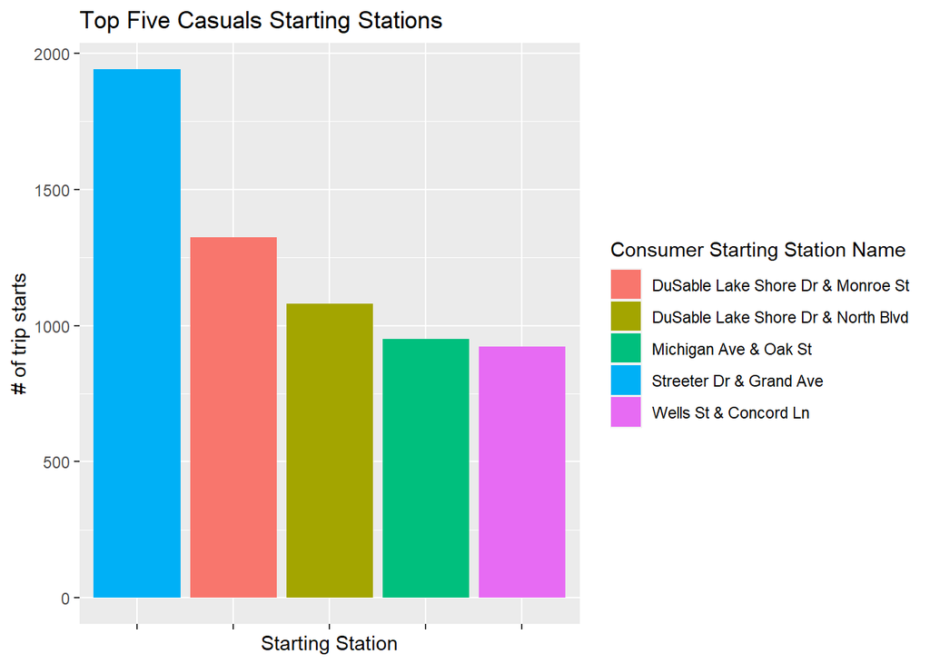

```r
ggplot(data = BD_0523_filtered_c, aes(x = start_station_name, fill = start_station_name)) +
  geom_bar() + scale_x_discrete(limits=c("Streeter Dr & Grand Ave", "DuSable Lake Shore Dr & Monroe St", "DuSable Lake Shore Dr & North Blvd", "Michigan Ave & Oak St","Wells St & Concord Ln")) + theme(axis.text.x=element_blank()) + xlab("Starting Station") + ylab("# of trip starts") + labs(title="Top Five Casuals Starting Stations") + guides(fill=guide_legend(title="Consumer Starting Station Name"))
```

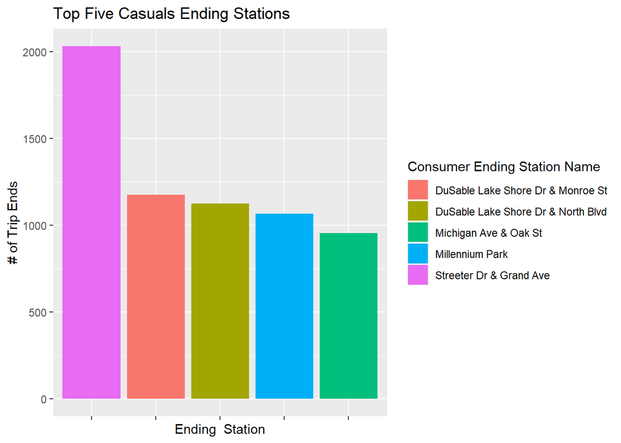

```r
ggplot(data = BD_0523_filtered_c, aes(x = end_station_name, fill = end_station_name)) +
  geom_bar() + scale_x_discrete(limits=c("Streeter Dr & Grand Ave", "DuSable Lake Shore Dr & Monroe St", "DuSable Lake Shore Dr & North Blvd", "Millennium Park","Michigan Ave & Oak St")) + theme(axis.text.x=element_blank()) + xlab("Ending  Station") + ylab("# of Trip Ends") + guides(fill=guide_legend(title="Consumer Ending Station Name"))  + labs(title="Top Five Casuals Ending Stations")
```

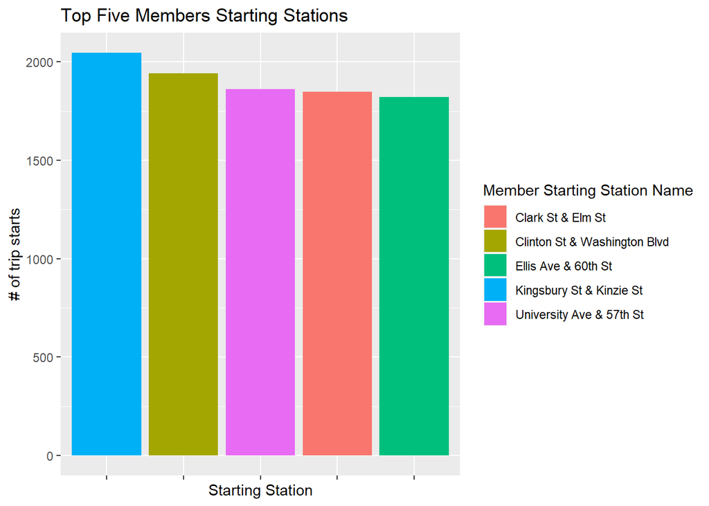

```r
ggplot(data = BD_0523_filtered_m, aes(x = start_station_name, fill = start_station_name)) +
  geom_bar() + scale_x_discrete(limits=c("Kingsbury St & Kinzie St", "Clinton St & Washington Blvd", "University Ave & 57th St", "Clark St & Elm St","Ellis Ave & 60th St")) + theme(axis.text.x=element_blank()) + xlab("Starting Station") + ylab("# of trip starts") + guides(fill=guide_legend(title="Member Starting Station Name"))  + labs(title="Top Five Members Starting Stations")
```

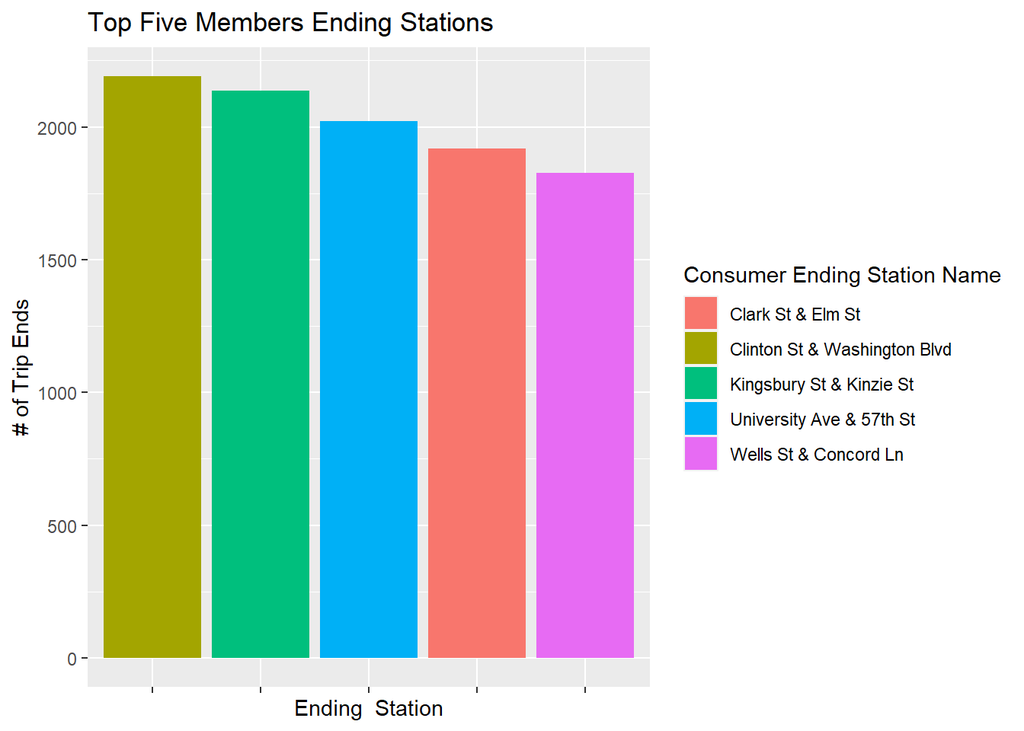

```r
ggplot(data = BD_0523_filtered_m, aes(x = end_station_name, fill = end_station_name)) +
  geom_bar() + scale_x_discrete(limits=c("Clinton St & Washington Blvd", "Kingsbury St & Kinzie St", "University Ave & 57th St", "Clark St & Elm St","Wells St & Concord Ln")) + theme(axis.text.x=element_blank()) + xlab("Ending  Station") + ylab("# of Trip Ends") + guides(fill=guide_legend(title="Consumer Ending Station Name"))  + labs(title="Top Five Members Ending Stations")
```

**Fig.5** **Bar Graph showing Days of the Week Utilization for Members vs. Casual**

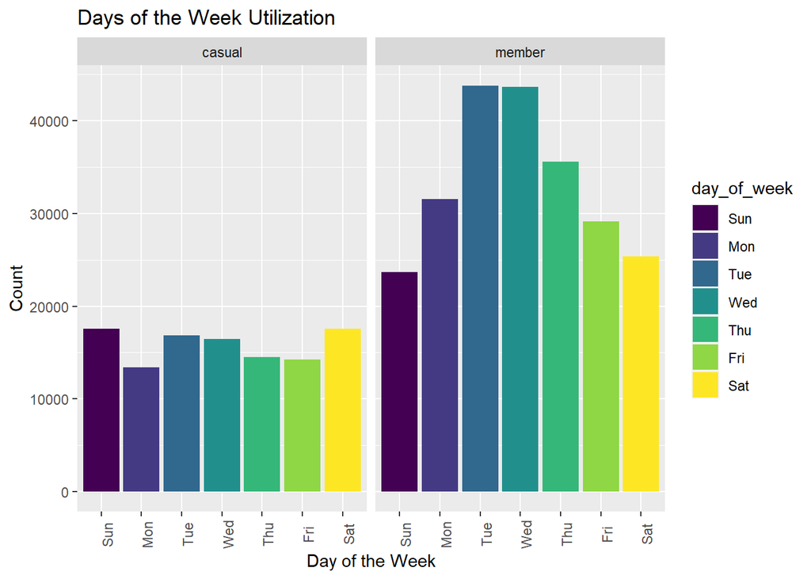

```r
ggplot(data=BD_0523_filtered) +
  geom_bar(mapping=aes(x=day_of_week, fill = day_of_week)) +
  labs(title="Days of the Week Utilization", x="Day of the Week", y="Count") +  theme(axis.text.x = element_text(angle = 90)) +
  facet_grid(~member_casual)
```

## **Phase 6: Act**

**Recommendations for Cyclistic Marketing Team**

1. Based off fig.5, the peak use days and minimal use days are reversed for Members and Casuals. To take advantage of this, the marketing team can run a promotion for annual passes during the weekend at the most popular spots for Casuals.
2. Based off fig.1-4, the starting and ending locations for Casuals are very similar. The marketing team can work to have extra annual memberships promotions posted around those areas.
3. Based off fig.5, and the fact provided by Cyclistic that over 30% of Members use the bikes for commuting purposes, Cyclistic can reach out to that subsection for testimonials about the convenience and cost-savings of commuting to work with Cyclistic bikes.

**Recommendations based on limitations of dataset**

1. Due to the missing PII, we cannot look at specific individuals. This additional data may show income/location based reasons for membership. It would also help identify average # of rides for Members Vs. Casuals
2. Since there is only quantitative data on the bikes themselves we do not know the human reasons why Casuals are not signing up for memberships.
3. Since we are only checking May, there may be differences in use in colder months.